# Assignment - Advanced Regression

Author:

- **G Kranthi Kiran** : [GitHub](https://github.com/kranthik13/)

## Problem Statement Understanding

US-based housing company named Surprise Housing has decided to enter the Australian market. The company uses data analytics to purchase houses at a price below their actual values and flip them on at a higher price.

The company is looking at prospective properties to buy to enter the market. You are required to build a regression model using regularisation in order to predict the actual value of the prospective properties and decide whether to invest in them or not. The company wants to know:

```
- Which variables are significant in predicting the price of a house, and
- How well those variables describe the price of a house.
```

Also, determine the optimal value of lambda for ridge and lasso regression.

## Objectives

The objectives for the solution are :

- Model the price of houses with the available **independent variables** for management to understand the **pricing dynamics** of a new market.
- They can **accordingly manipulate the strategy of the firm** and concentrate on areas that will **yield high returns.**

## Index :

1. Data Understanding
2. Data Cleaning and Manipulation
3. Exploratory Data Analysis
4. Data Preparation + Feature Engineering
5. Model Building
6. Final Model Selection
7. Conclusion

## 1. Data Understanding

#### Loading Libraries

```python
import pandas as pd
import numpy as np

from sklearn.model_selection import cross_val_score, train_test_split
from sklearn.feature_selection import RFE
from sklearn.preprocessing import StandardScaler
from sklearn.linear_model import LinearRegression, RidgeCV, LassoCV, Ridge, Lasso
from sklearn.model_selection import GridSearchCV
from sklearn.metrics import mean_squared_error, r2_score
from scipy.stats import skew

import seaborn as sns
import matplotlib.pyplot as plt
import matplotlib.style as style
style.use('ggplot')

pd.options.display.max_rows = 500
pd.options.display.max_columns = 500
pd.options.display.precision = 4

import warnings
warnings.simplefilter('ignore')
```

```python
data = pd.read_csv('../data/train.csv')
```

```python
data.head()
```

|  | Id | MSSubClass | MSZoning | LotFrontage | LotArea | Street | Alley | LotShape | LandContour | Utilities | LotConfig | LandSlope | Neighborhood | Condition1 | Condition2 | BldgType | HouseStyle | OverallQual | OverallCond | YearBuilt | YearRemodAdd | RoofStyle | RoofMatl | Exterior1st | Exterior2nd | MasVnrType | MasVnrArea | ExterQual | ExterCond | … |
| --- | --- | --- | --- | --- | --- | --- | --- | --- | --- | --- | --- | --- | --- | --- | --- | --- | --- | --- | --- | --- | --- | --- | --- | --- | --- | --- | --- | --- | --- | --- |
| 0 | 1 | 60 | RL | 65.0 | 8450 | Pave | NaN | Reg | Lvl | AllPub | Inside | Gtl | CollgCr | Norm | Norm | 1Fam | 2Story | 7 | 5 | 2003 | 2003 | Gable | CompShg | VinylSd | VinylSd | BrkFace | 196.0 | Gd | TA | … |
| 1 | 2 | 20 | RL | 80.0 | 9600 | Pave | NaN | Reg | Lvl | AllPub | FR2 | Gtl | Veenker | Feedr | Norm | 1Fam | 1Story | 6 | 8 | 1976 | 1976 | Gable | CompShg | MetalSd | MetalSd | None | 0.0 | TA | TA | … |
| 2 | 3 | 60 | RL | 68.0 | 11250 | Pave | NaN | IR1 | Lvl | AllPub | Inside | Gtl | CollgCr | Norm | Norm | 1Fam | 2Story | 7 | 5 | 2001 | 2002 | Gable | CompShg | VinylSd | VinylSd | BrkFace | 162.0 | Gd | TA | … |
| 3 | 4 | 70 | RL | 60.0 | 9550 | Pave | NaN | IR1 | Lvl | AllPub | Corner | Gtl | Crawfor | Norm | Norm | 1Fam | 2Story | 7 | 5 | 1915 | 1970 | Gable | CompShg | Wd Sdng | Wd Shng | None | 0.0 | TA | TA | … |
| 4 | 5 | 60 | RL | 84.0 | 14260 | Pave | NaN | IR1 | Lvl | AllPub | FR2 | Gtl | NoRidge | Norm | Norm | 1Fam | 2Story | 8 | 5 | 2000 | 2000 | Gable | CompShg | VinylSd | VinylSd | BrkFace | 350.0 | Gd | TA | … |

```python
data.info()
```

```
<class 'pandas.core.frame.DataFrame'>
RangeIndex: 1460 entries, 0 to 1459
Data columns (total 81 columns):
 #   Column         Non-Null Count  Dtype
---  ------         --------------  -----
 0   Id             1460 non-null   int64
 1   MSSubClass     1460 non-null   int64
 2   MSZoning       1460 non-null   object
 3   LotFrontage    1201 non-null   float64
 4   LotArea        1460 non-null   int64
 5   Street         1460 non-null   object
 6   Alley          91 non-null     object
 7   LotShape       1460 non-null   object
 8   LandContour    1460 non-null   object
 9   Utilities      1460 non-null   object
```

[output cut: 73 more lines]

```python
data.shape
```

```
(1460, 81)
```

Target Variable : **SalePrice**

## 2. Data Cleaning and Preprocessing

#### 1. Checking for Null Values

```python
def get_null_cols(df):
    res = (df.isnull().sum() / df.shape[0]).sort_values(ascending=False).reset_index(drop=False)
    res.rename({
        "index": "column_name",
        0: "null_percentage",
    }, axis=1, inplace=True)
    res['null_percentage'] = res['null_percentage'] * 100
    res = res[res['null_percentage'] != 0]
    res.reset_index(drop=True, inplace=True)

    print(f"Columns with Null values : {res.shape[0]}")
    print(f"Columns with full nulls : {res[res['null_percentage'] == 100].shape[0]}")

    return res

null_cols = get_null_cols(data)
null_cols
```

```
Columns with Null values : 19
Columns with full nulls : 0
```

|  | column_name | null_percentage |
| --- | --- | --- |
| 0 | PoolQC | 99.5205 |
| 1 | MiscFeature | 96.3014 |
| 2 | Alley | 93.7671 |
| 3 | Fence | 80.7534 |
| 4 | FireplaceQu | 47.2603 |
| 5 | LotFrontage | 17.7397 |
| 6 | GarageYrBlt | 5.5479 |
| 7 | GarageCond | 5.5479 |
| 8 | GarageType | 5.5479 |
| 9 | GarageFinish | 5.5479 |
| 10 | GarageQual | 5.5479 |
| 11 | BsmtFinType2 | 2.6027 |
| 12 | BsmtExposure | 2.6027 |
| 13 | BsmtQual | 2.5342 |
| 14 | BsmtCond | 2.5342 |
| 15 | BsmtFinType1 | 2.5342 |
| 16 | MasVnrArea | 0.5479 |
| 17 | MasVnrType | 0.5479 |
| 18 | Electrical | 0.0685 |

#### Removing ID columns

```python
data = data.drop(['Id'], 1)
```

#### Removing columns with more than **17%** data missing as imputation might extrapolate our assumptions and include exaggeration of our data

```python
null_cols[null_cols['null_percentage'] > 17]
```

|  | column_name | null_percentage |
| --- | --- | --- |
| 0 | PoolQC | 99.5205 |
| 1 | MiscFeature | 96.3014 |
| 2 | Alley | 93.7671 |
| 3 | Fence | 80.7534 |
| 4 | FireplaceQu | 47.2603 |
| 5 | LotFrontage | 17.7397 |

```python
data.drop(null_cols[null_cols['null_percentage'] > 17]['column_name'], axis=1, inplace=True)
```

```python
null_cols_new = get_null_cols(data)
null_cols_new
```

```
Columns with Null values : 13
Columns with full nulls : 0
```

|  | column_name | null_percentage |
| --- | --- | --- |
| 0 | GarageType | 5.5479 |
| 1 | GarageYrBlt | 5.5479 |
| 2 | GarageFinish | 5.5479 |
| 3 | GarageQual | 5.5479 |
| 4 | GarageCond | 5.5479 |
| 5 | BsmtFinType2 | 2.6027 |
| 6 | BsmtExposure | 2.6027 |
| 7 | BsmtQual | 2.5342 |
| 8 | BsmtCond | 2.5342 |
| 9 | BsmtFinType1 | 2.5342 |
| 10 | MasVnrArea | 0.5479 |
| 11 | MasVnrType | 0.5479 |
| 12 | Electrical | 0.0685 |

#### Even if we remove all the rows which includes atleast one null we'd still have enough amount of data left for modelling i.e. not humongous reduction (122 records)

```python
data = data.dropna()
```

```python
data.shape
```

```
(1338, 74)
```

#### Remaining Columns

```python
data.columns.tolist()
```

```
['MSSubClass',
 'MSZoning',
 'LotArea',
 'Street',
 'LotShape',
 'LandContour',
 'Utilities',
 'LotConfig',
 'LandSlope',
 'Neighborhood',
 'Condition1',
 'Condition2',
 'BldgType',
 'HouseStyle',
 'OverallQual',
 'OverallCond',
 'YearBuilt',
 'YearRemodAdd',
 'RoofStyle',
 'RoofMatl',
 'Exterior1st',
 'Exterior2nd',
 'MasVnrType',
 'MasVnrArea',
 'ExterQual',
 'ExterCond',
 'Foundation',
 'BsmtQual',
 'BsmtCond',
 'BsmtExposure',
 'BsmtFinType1',
 'BsmtFinSF1',
 'BsmtFinType2',
 'BsmtFinSF2',
 'BsmtUnfSF',
 'TotalBsmtSF',
 'Heating',
 'HeatingQC',
 'CentralAir',
 'Electrical',
```

[output cut: 19 more lines]

```
 'GarageQual',
 'GarageCond',
 'PavedDrive',
 'WoodDeckSF',
 'OpenPorchSF',
 'EnclosedPorch',
 '3SsnPorch',
 'ScreenPorch',
 'PoolArea',
 'MiscVal',
 'MoSold',
 'YrSold',
 'SaleType',
 'SaleCondition',
 'SalePrice']
```

## 3. Exploratory Data Analysis

#### 1. Univariate Analysis

#### SalePrice

```python
data['SalePrice'].describe()
```

```
count      1338.0000
mean     186761.7825
std       78913.8477
min       35311.0000
25%      135000.0000
50%      168500.0000
75%      220000.0000
max      755000.0000
Name: SalePrice, dtype: float64
```

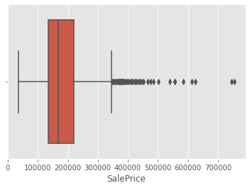

```python
sns.boxplot(data['SalePrice'])
plt.show()
```

We can see here that it is very much right skewed i.e. too many outliers on the right tail.

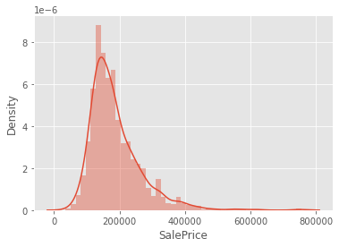

```python
sns.distplot(data['SalePrice'])
plt.show()
```

#### GrLivArea

```python
data['GrLivArea'].describe()
```

```
count    1338.0000
mean     1537.5852
std       520.5800
min       438.0000
25%      1160.0000
50%      1480.0000
75%      1791.5000
max      5642.0000
Name: GrLivArea, dtype: float64
```

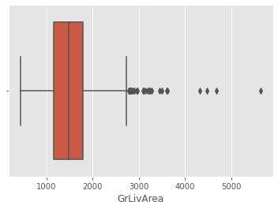

```python
sns.boxplot(data['GrLivArea'])
plt.show()
```

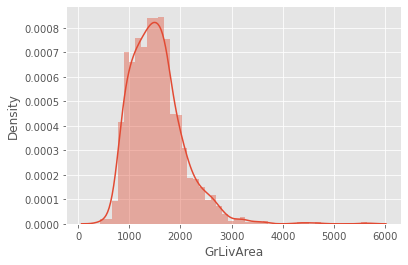

```python
sns.distplot(data['GrLivArea'])
plt.show()
```

We can see here that it is very much right skewed i.e. too many outliers on the right tail.

#### BsmtHalfBath

```python
data['BsmtHalfBath'].value_counts(normalize=True) * 100
```

```
0    94.0209
1     5.9043
2     0.0747
Name: BsmtHalfBath, dtype: float64
```

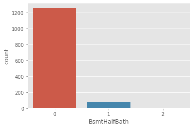

```python
g = sns.countplot(data=data,x='BsmtHalfBath')
plt.show()
```

Most of the records have no half baths!

#### Street, Utilities, LotShape, LandContour

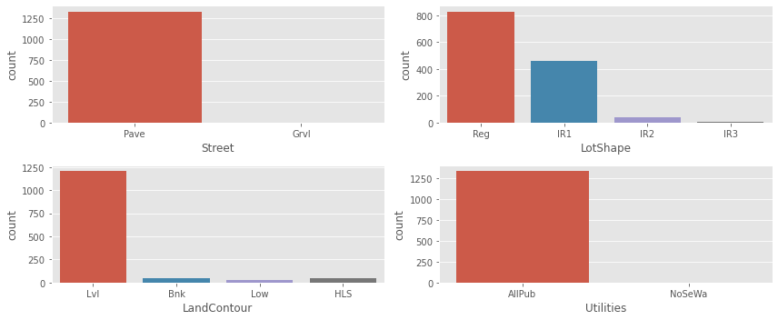

```python
plt.figure(figsize=[12, 5])
plt.subplot(2,2,1)
g = sns.countplot(data=data, x='Street')
plt.subplot(2,2,2)
g = sns.countplot(data=data, x='LotShape')
plt.subplot(2,2,3)
g = sns.countplot(data=data, x='LandContour')
plt.subplot(2,2,4)
g = sns.countplot(data=data, x='Utilities')
plt.tight_layout()
plt.show()
```

These categorical columns have very imbalanced distribution i.e. most of the records are from 1 cateogry only except the **LotShape** column.

#### OverallCond

```python
data['OverallCond'].value_counts(normalize=True) * 100
```

```
5    57.5486
6    17.4141
7    13.6771
8     5.0822
4     3.4380
9     1.4948
3     1.1211
2     0.2242
Name: OverallCond, dtype: float64
```

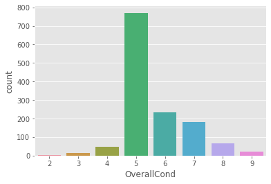

```python
g = sns.countplot(data=data,x='OverallCond')
plt.show()
```

#### ExterCond

```python
data['ExterCond'].value_counts(normalize=True) * 100
```

```
TA    88.4155
Gd    10.2392
Fa     1.1958
Ex     0.1495
Name: ExterCond, dtype: float64
```

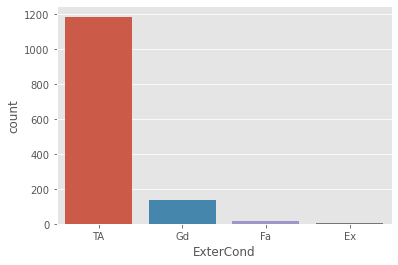

```python
g = sns.countplot(data=data,x='ExterCond',orient='h')
plt.show()
```

### 2. Bivariate Analysis

- PairPlotting multiple features against our target **SalePrice**

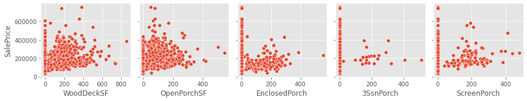

```python
pairplot = sns.pairplot(
    data,
    y_vars=['SalePrice'],
    x_vars=['WoodDeckSF', 'OpenPorchSF', 'EnclosedPorch', '3SsnPorch', 'ScreenPorch']
)
plt.tight_layout()
plt.show()
```

- The below plot shows the distribution of SalePrice compared to different types of Sales.

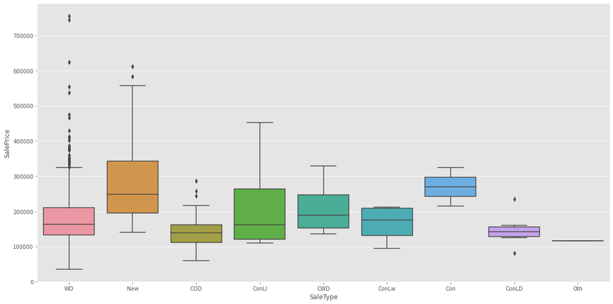

```python
plt.figure(figsize = (16, 8))
sns.boxplot(x = 'SaleType', y = 'SalePrice', data = data)
plt.tight_layout()
plt.show()
```

### Correlation Analysis

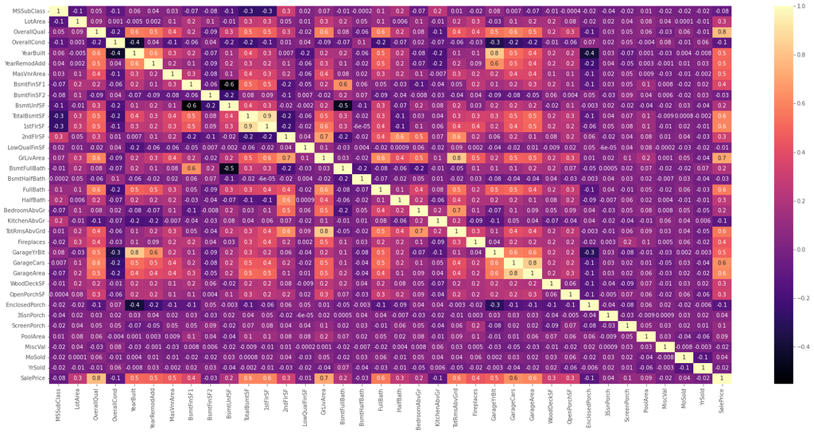

```python
plt.figure(figsize = (28, 28))
plt.subplot(2, 1, 1)
sns.heatmap(data.corr(), cmap="magma", annot = True, fmt='0.1g')
plt.show()
```

### Some features which are highly correlated :

- **SalePrice & OverallQual (0.8)** - High Finish houses have high prices
- **YearBuilt & GarageYrBlt (0.8)** - Usually garages are built on the same year as the house
- **SalePrice & GrLivArea (0.7)** - More the area of the house more the price
- **SalePrice & multiple features** listed below : (most of the below features have **correlation of 0.6**)
  - **TotalRmsAbvGrd**
  - **GarageCars**
  - **GarageArea**
  - **FullBath**
  - **1stFlrSF**
  - **TotalBsmtSF**

## 4. Data Preparation + Feature Engineering

#### Feature Engineering

- Whole bathroom are with a formulae
- Total Surface Area with a formulae

```python
data['total_bathroom_area'] = data['FullBath'] + data['BsmtFullBath'] + 0.5 * (data['BsmtHalfBath'] + data['HalfBath'])
data['total_sf_area'] = data['TotalBsmtSF'] + data['GrLivArea']
```

New Neighborhood category feature created from the data dictionary

```python
data["nice_neighborhood"] = 0
data['nice_neighborhood'] = np.where(data['Neighborhood'] == 'NridgHt', 1, 0)
data['nice_neighborhood'] = np.where(data['Neighborhood'] == 'Crawfor', 1, 0)
data['nice_neighborhood'] = np.where(data['Neighborhood'] == 'StoneBr', 1, 0)
data['nice_neighborhood'] = np.where(data['Neighborhood'] == 'Somerst', 1, 0)
data['nice_neighborhood'] = np.where(data['Neighborhood'] == 'NoRidge', 1, 0)
```

Derived Time features

- Assumption : Max Year is 2010

Features:

- Age of house
- "Years Passed Since" features

```python
data["age"] = 2010 - data["YearBuilt"]
data["years_passed_since_sold"] = 2010 - data["YrSold"]
data["years_passed_since_garageblt"] = 2010 - data["GarageYrBlt"]
```

```python
data["Remodel_Flag"] = (data["YearRemodAdd"] != data["YearBuilt"]) * 1
data["RecentRemodel_Flag"] = (data["YearRemodAdd"] == data["YrSold"]) * 1
```

```python
data.drop(['YearBuilt', 'YearRemodAdd', 'GarageYrBlt', 'YrSold'], axis=1, inplace=True)
```

Clustering the existing feature buckets into smaller and concise groups

```python
### 1-3 == Low Cluster
### 4-6 == Medium Cluster
### 7-10 == Best Cluster

cluster_mapping = {
    1:1,
    2:1,
    3:1,
    4:2,
    5:2,
    6:2,
    7:3,
    8:3,
    9:3,
    10:3,
}

data['OverallQual_simpleclusters'] = data['OverallQual'].apply(lambda x: cluster_mapping[x])
data['OverallCond_simpleclusters'] = data['OverallCond'].apply(lambda x: cluster_mapping[x])
```

```python
data.head()
```

|  | MSSubClass | MSZoning | LotArea | Street | LotShape | LandContour | Utilities | LotConfig | LandSlope | Neighborhood | Condition1 | Condition2 | BldgType | HouseStyle | OverallQual | OverallCond | RoofStyle | RoofMatl | Exterior1st | Exterior2nd | MasVnrType | MasVnrArea | ExterQual | ExterCond | Foundation | BsmtQual | BsmtCond | BsmtExposure | BsmtFinType1 | … |
| --- | --- | --- | --- | --- | --- | --- | --- | --- | --- | --- | --- | --- | --- | --- | --- | --- | --- | --- | --- | --- | --- | --- | --- | --- | --- | --- | --- | --- | --- | --- |
| 0 | 60 | RL | 8450 | Pave | Reg | Lvl | AllPub | Inside | Gtl | CollgCr | Norm | Norm | 1Fam | 2Story | 7 | 5 | Gable | CompShg | VinylSd | VinylSd | BrkFace | 196.0 | Gd | TA | PConc | Gd | TA | No | GLQ | … |
| 1 | 20 | RL | 9600 | Pave | Reg | Lvl | AllPub | FR2 | Gtl | Veenker | Feedr | Norm | 1Fam | 1Story | 6 | 8 | Gable | CompShg | MetalSd | MetalSd | None | 0.0 | TA | TA | CBlock | Gd | TA | Gd | ALQ | … |
| 2 | 60 | RL | 11250 | Pave | IR1 | Lvl | AllPub | Inside | Gtl | CollgCr | Norm | Norm | 1Fam | 2Story | 7 | 5 | Gable | CompShg | VinylSd | VinylSd | BrkFace | 162.0 | Gd | TA | PConc | Gd | TA | Mn | GLQ | … |
| 3 | 70 | RL | 9550 | Pave | IR1 | Lvl | AllPub | Corner | Gtl | Crawfor | Norm | Norm | 1Fam | 2Story | 7 | 5 | Gable | CompShg | Wd Sdng | Wd Shng | None | 0.0 | TA | TA | BrkTil | TA | Gd | No | ALQ | … |
| 4 | 60 | RL | 14260 | Pave | IR1 | Lvl | AllPub | FR2 | Gtl | NoRidge | Norm | Norm | 1Fam | 2Story | 8 | 5 | Gable | CompShg | VinylSd | VinylSd | BrkFace | 350.0 | Gd | TA | PConc | Gd | TA | Av | GLQ | … |

#### Feature Division

Categorical Columns

```python
cat_col = ['MSSubClass', 'MSZoning', 'Street', 'LotShape', 'LandContour', 'Utilities', 'LotConfig', 'LandSlope',
           'Neighborhood', 'Condition1', 'Condition2', 'BldgType', 'HouseStyle', 'OverallQual', 'OverallCond',
           'RoofStyle', 'RoofMatl', 'Exterior1st', 'Exterior2nd', 'MasVnrType', 'ExterQual', 'ExterCond',
           'Foundation', 'BsmtQual', 'BsmtCond', 'BsmtExposure', 'BsmtFinType1', 'BsmtFinType2', 'Heating',
           'HeatingQC', 'CentralAir', 'Electrical', 'KitchenQual', 'Functional', 'GarageType', 'GarageFinish',
           'GarageQual', 'GarageCond', 'PavedDrive', 'MoSold', 'SaleType', 'SaleCondition',
           'nice_neighborhood','Remodel_Flag','RecentRemodel_Flag']
```

Numerical Columns

```python
num_col = list(set(data.columns.tolist()) - set(cat_col))
print(num_col)
```

```
['BsmtFinSF2', 'BsmtUnfSF', 'years_passed_since_sold', 'MasVnrArea', 'BsmtFullBath', 'FullBath', 'total_bathroom_area', 'EnclosedPorch', 'BsmtFinSF1', 'years_passed_since_garageblt', 'TotalBsmtSF', '1stFlrSF', 'SalePrice', 'OverallCond_simpleclusters', 'ScreenPorch', 'GrLivArea', 'BsmtHalfBath', 'Mi…
```

```python
data.shape
```

```
(1338, 80)
```

### Target Distribution

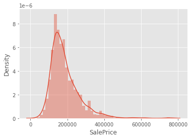

```python
sns.distplot((data["SalePrice"]))
plt.show()
```

#### Log Transforming SalePrice as regressing on log transformed skewed target cariable would be a better fit than the normal one.

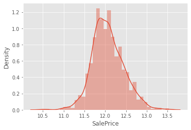

```python
sns.distplot(np.log1p(data["SalePrice"]))
plt.show()
```

#### Checking skewness in all the other features also!

```python
skewness = data[num_col].apply(skew)
skewness = skewness[abs(skewness) > 0.75]
skewed_features = skewness.index
```

```python
skewed_features
```

```
Index(['BsmtFinSF2', 'BsmtUnfSF', 'MasVnrArea', 'EnclosedPorch', 'BsmtFinSF1',
       'TotalBsmtSF', '1stFlrSF', 'SalePrice', 'OverallCond_simpleclusters',
       'ScreenPorch', 'GrLivArea', 'BsmtHalfBath', 'MiscVal', '2ndFlrSF',
       'OpenPorchSF', '3SsnPorch', 'WoodDeckSF', 'PoolArea', 'KitchenAbvGr',
       'LowQualFinSF', 'total_sf_area', 'LotArea', 'GarageArea'],
      dtype='object')
```

```python
data[skewed_features] = data[skewed_features].applymap(np.log1p)
```

Log Transformation for skewed features will help in reducing the impact of outliers too!

#### Dummy-fying the Categorical Columns

```python
data = pd.get_dummies(data, columns=cat_col,drop_first=True)
print(f"Data Shape after feature engineering : {data.shape}")
```

```
Data Shape after feature engineering : (1338, 269)
```

```python
data.head()
```

|  | LotArea | MasVnrArea | BsmtFinSF1 | BsmtFinSF2 | BsmtUnfSF | TotalBsmtSF | 1stFlrSF | 2ndFlrSF | LowQualFinSF | GrLivArea | BsmtFullBath | BsmtHalfBath | FullBath | HalfBath | BedroomAbvGr | KitchenAbvGr | TotRmsAbvGrd | Fireplaces | GarageCars | GarageArea | WoodDeckSF | OpenPorchSF | EnclosedPorch | 3SsnPorch | ScreenPorch | PoolArea | MiscVal | SalePrice | total_bathroom_area | … |
| --- | --- | --- | --- | --- | --- | --- | --- | --- | --- | --- | --- | --- | --- | --- | --- | --- | --- | --- | --- | --- | --- | --- | --- | --- | --- | --- | --- | --- | --- | --- |
| 0 | 9.0420 | 5.2832 | 6.5610 | 0.0 | 5.0173 | 6.7534 | 6.7534 | 6.7511 | 0.0 | 7.4448 | 1 | 0.0000 | 2 | 1 | 3 | 0.6931 | 8 | 0 | 2 | 6.3081 | 0.0000 | 4.1271 | 0.0000 | 0.0 | 0.0 | 0.0 | 0.0 | 12.2477 | 3.5 | … |
| 1 | 9.1696 | 0.0000 | 6.8865 | 0.0 | 5.6525 | 7.1412 | 7.1412 | 0.0000 | 0.0 | 7.1412 | 0 | 0.6931 | 2 | 0 | 3 | 0.6931 | 6 | 1 | 2 | 6.1334 | 5.7004 | 0.0000 | 0.0000 | 0.0 | 0.0 | 0.0 | 0.0 | 12.1090 | 2.5 | … |
| 2 | 9.3282 | 5.0938 | 6.1883 | 0.0 | 6.0753 | 6.8255 | 6.8255 | 6.7650 | 0.0 | 7.4883 | 1 | 0.0000 | 2 | 1 | 3 | 0.6931 | 6 | 1 | 2 | 6.4118 | 0.0000 | 3.7612 | 0.0000 | 0.0 | 0.0 | 0.0 | 0.0 | 12.3172 | 3.5 | … |
| 3 | 9.1644 | 0.0000 | 5.3799 | 0.0 | 6.2934 | 6.6294 | 6.8690 | 6.6294 | 0.0 | 7.4489 | 1 | 0.0000 | 1 | 0 | 3 | 0.6931 | 7 | 1 | 3 | 6.4661 | 0.0000 | 3.5835 | 5.6095 | 0.0 | 0.0 | 0.0 | 0.0 | 11.8494 | 2.0 | … |
| 4 | 9.5653 | 5.8608 | 6.4862 | 0.0 | 6.1964 | 7.0440 | 7.0440 | 6.9603 | 0.0 | 7.6958 | 1 | 0.0000 | 2 | 1 | 4 | 0.6931 | 9 | 1 | 3 | 6.7298 | 5.2627 | 4.4427 | 0.0000 | 0.0 | 0.0 | 0.0 | 0.0 | 12.4292 | 3.5 | … |

### Standardizing the Numerical Columns

```python
scaler = StandardScaler()
data[num_col] = scaler.fit_transform(data[num_col])
```

```python
data.head()
```

|  | LotArea | MasVnrArea | BsmtFinSF1 | BsmtFinSF2 | BsmtUnfSF | TotalBsmtSF | 1stFlrSF | 2ndFlrSF | LowQualFinSF | GrLivArea | BsmtFullBath | BsmtHalfBath | FullBath | HalfBath | BedroomAbvGr | KitchenAbvGr | TotRmsAbvGrd | Fireplaces | GarageCars | GarageArea | WoodDeckSF | OpenPorchSF | EnclosedPorch | 3SsnPorch | ScreenPorch | PoolArea | MiscVal | SalePrice | total_bathroom_area | … |
| --- | --- | --- | --- | --- | --- | --- | --- | --- | --- | --- | --- | --- | --- | --- | --- | --- | --- | --- | --- | --- | --- | --- | --- | --- | --- | --- | --- | --- | --- | --- |
| 0 | -0.1648 | 1.1377 | 0.7371 | -0.3669 | -0.4885 | -0.5243 | -0.8555 | 1.1566 | -0.1159 | 0.4923 | 1.0889 | -0.2516 | 0.7756 | 1.1848 | 0.1742 | -0.1722 | 0.9151 | -1.0055 | 0.2027 | 0.4169 | -0.9874 | 0.8111 | -0.3948 | -0.1314 | -0.307 | -0.0725 | -0.1891 | 0.4890 | 1.6351 | … |
| 1 | 0.0823 | -0.8521 | 0.8481 | -0.3669 | -0.0945 | 0.5732 | 0.3830 | -0.8859 | -0.1159 | -0.4498 | -0.8511 | 3.9262 | 0.7756 | -0.7993 | 0.1742 | -0.1722 | -0.3472 | 0.5445 | 0.2027 | -0.0437 | 1.2013 | -1.1189 | -0.3948 | -0.1314 | -0.307 | -0.0725 | -0.1891 | 0.1208 | 0.3313 | … |
| 2 | 0.3894 | 1.0663 | 0.6099 | -0.3669 | 0.1678 | -0.3205 | -0.6255 | 1.1608 | -0.1159 | 0.6271 | 1.0889 | -0.2516 | 0.7756 | 1.1848 | 0.1742 | -0.1722 | -0.3472 | 0.5445 | 0.2027 | 0.6903 | -0.9874 | 0.6399 | -0.3948 | -0.1314 | -0.307 | -0.0725 | -0.1891 | 0.6734 | 1.6351 | … |
| 3 | 0.0721 | -0.8521 | 0.3340 | -0.3669 | 0.3031 | -0.8755 | -0.4864 | 1.1197 | -0.1159 | 0.5049 | 1.0889 | -0.2516 | -1.0514 | -0.7993 | 0.1742 | -0.1722 | 0.2840 | 0.5445 | 1.7799 | 0.8335 | -0.9874 | 0.5569 | 2.9064 | -0.1314 | -0.307 | -0.0725 | -0.1891 | -0.5683 | -0.3206 | … |
| 4 | 0.8486 | 1.3552 | 0.7115 | -0.3669 | 0.2429 | 0.2981 | 0.0726 | 1.2199 | -0.1159 | 1.2709 | 1.0889 | -0.2516 | 0.7756 | 1.1848 | 1.4623 | -0.1722 | 1.5462 | 0.5445 | 1.7799 | 1.5287 | 1.0333 | 0.9586 | -0.3948 | -0.1314 | -0.307 | -0.0725 | -0.1891 | 0.9708 | 1.6351 | … |

## 5. Model Building

- Train Test Split [70:30]

```python
target = 'SalePrice'

X = data.drop([target], 1)
y = data[target]
```

```python
X_train, X_test, y_train, y_test = train_test_split(X, y, test_size=0.3, random_state=13)

print(f"Train Size : {X_train.shape}")
print(f"Test Size : {X_test.shape}")
```

```
Train Size : (936, 268)
Test Size : (402, 268)
```

### Running RFE for RandomForest for 1st Level of Feature Selection

```python
from sklearn.ensemble import RandomForestRegressor

lm = RandomForestRegressor(n_estimators=100, n_jobs=-1, random_state=13)
lm.fit(X_train, y_train)
```

```
RandomForestRegressor(n_jobs=-1, random_state=13)
```

```python
rfe = RFE(lm, n_features_to_select=66)
rfe = rfe.fit(X_train, y_train)
```

```python
list(zip(X_train.columns,rfe.support_,rfe.ranking_))
```

```
[('LotArea', True, 1),
 ('MasVnrArea', True, 1),
 ('BsmtFinSF1', True, 1),
 ('BsmtFinSF2', True, 1),
 ('BsmtUnfSF', True, 1),
 ('TotalBsmtSF', True, 1),
 ('1stFlrSF', True, 1),
 ('2ndFlrSF', True, 1),
 ('LowQualFinSF', False, 90),
 ('GrLivArea', True, 1),
 ('BsmtFullBath', True, 1),
 ('BsmtHalfBath', False, 48),
 ('FullBath', True, 1),
 ('HalfBath', False, 6),
 ('BedroomAbvGr', True, 1),
 ('KitchenAbvGr', True, 1),
 ('TotRmsAbvGrd', True, 1),
 ('Fireplaces', True, 1),
 ('GarageCars', True, 1),
 ('GarageArea', True, 1),
 ('WoodDeckSF', True, 1),
 ('OpenPorchSF', True, 1),
 ('EnclosedPorch', True, 1),
 ('3SsnPorch', False, 86),
 ('ScreenPorch', False, 16),
 ('PoolArea', False, 153),
 ('MiscVal', False, 50),
 ('total_bathroom_area', True, 1),
 ('total_sf_area', True, 1),
 ('age', True, 1),
 ('years_passed_since_sold', True, 1),
 ('years_passed_since_garageblt', True, 1),
 ('OverallQual_simpleclusters', True, 1),
 ('OverallCond_simpleclusters', True, 1),
 ('MSSubClass_30', False, 25),
 ('MSSubClass_40', False, 160),
 ('MSSubClass_45', False, 134),
 ('MSSubClass_50', True, 1),
 ('MSSubClass_60', False, 44),
 ('MSSubClass_70', False, 99),
```

[output cut: 213 more lines]

```
 ('SaleType_Con', False, 157),
 ('SaleType_ConLD', False, 177),
 ('SaleType_ConLI', False, 198),
 ('SaleType_ConLw', False, 138),
 ('SaleType_New', False, 77),
 ('SaleType_Oth', False, 171),
 ('SaleType_WD', False, 29),
 ('SaleCondition_AdjLand', False, 172),
 ('SaleCondition_Alloca', False, 141),
 ('SaleCondition_Family', True, 1),
 ('SaleCondition_Normal', True, 1),
 ('SaleCondition_Partial', False, 11),
 ('nice_neighborhood_1', False, 122),
 ('Remodel_Flag_1', False, 5),
 ('RecentRemodel_Flag_1', False, 56)]
```

```python
cols = X_train.columns[rfe.support_]
cols
```

```
Index(['LotArea', 'MasVnrArea', 'BsmtFinSF1', 'BsmtFinSF2', 'BsmtUnfSF',
       'TotalBsmtSF', '1stFlrSF', '2ndFlrSF', 'GrLivArea', 'BsmtFullBath',
       'FullBath', 'BedroomAbvGr', 'KitchenAbvGr', 'TotRmsAbvGrd',
       'Fireplaces', 'GarageCars', 'GarageArea', 'WoodDeckSF', 'OpenPorchSF',
       'EnclosedPorch', 'total_bathroom_area', 'total_sf_area', 'age',
       'years_passed_since_sold', 'years_passed_since_garageblt',
       'OverallQual_simpleclusters', 'OverallCond_simpleclusters',
       'MSSubClass_50', 'MSZoning_RL', 'MSZoning_RM', 'LotShape_Reg',
       'LandContour_Lvl', 'Neighborhood_Crawfor', 'Neighborhood_Edwards',
       'Neighborhood_IDOTRR', 'OverallQual_4', 'OverallQual_5',
       'OverallQual_6', 'OverallQual_7', 'OverallQual_8', 'OverallQual_9',
       'OverallCond_4', 'OverallCond_5', 'OverallCond_7', 'RoofStyle_Gable',
       'Exterior1st_BrkFace', 'Exterior2nd_VinylSd', 'ExterQual_Gd',
       'ExterQual_TA', 'ExterCond_Fa', 'BsmtQual_Fa', 'BsmtQual_Gd',
       'BsmtExposure_No', 'BsmtFinType1_GLQ', 'BsmtFinType2_BLQ',
       'HeatingQC_TA', 'CentralAir_Y', 'Electrical_SBrkr', 'KitchenQual_Gd',
       'KitchenQual_TA', 'Functional_Typ', 'GarageType_Attchd',
       'GarageType_Detchd', 'GarageFinish_Unf', 'SaleCondition_Family',
       'SaleCondition_Normal'],
      dtype='object')
```

```python
X_train = X_train[cols]
```

### Model 1 - Ridge

The first model would be **Ridge Regression** Model. To find the best alpha value let's use **GridSearch.**

To select the best model and for cross-validation purpose I'm using the **R2 Score** as a metric

```python
params = {
    'alpha': [0.0001, 0.001, 0.01, 0.05,
              0.1, 0.2, 0.3, 0.4, 0.5, 0.6, 0.7, 0.8, 0.9,
              1.0, 2.0, 3.0, 4.0, 5.0, 6.0, 7.0, 8.0, 9.0, 10.0,
              20, 50, 100, 500, 1000
             ]
}
```

```python
ridge = Ridge()

# 5 Cross Validation
folds = 5
model_cv = GridSearchCV(
    estimator = ridge,
    param_grid = params,
    scoring= 'r2',
    cv = folds,
    return_train_score=True,
    verbose = 1,
    n_jobs=-1
)

model_cv.fit(X_train, y_train)
```

```
Fitting 5 folds for each of 28 candidates, totalling 140 fits
```

```
GridSearchCV(cv=5, estimator=Ridge(), n_jobs=-1,
             param_grid={'alpha': [0.0001, 0.001, 0.01, 0.05, 0.1, 0.2, 0.3,
                                   0.4, 0.5, 0.6, 0.7, 0.8, 0.9, 1.0, 2.0, 3.0,
                                   4.0, 5.0, 6.0, 7.0, 8.0, 9.0, 10.0, 20, 50,
                                   100, 500, 1000]},
             return_train_score=True, scoring='r2', verbose=1)
```

#### Interpreting the CV Results for **Ridge Regression** Model

```python
cv_results = pd.DataFrame(model_cv.cv_results_)
cv_results.head()
```

|  | mean_fit_time | std_fit_time | mean_score_time | std_score_time | param_alpha | params | split0_test_score | split1_test_score | split2_test_score | split3_test_score | split4_test_score | mean_test_score | std_test_score | rank_test_score | split0_train_score | split1_train_score | split2_train_score | split3_train_score | split4_train_score | mean_train_score | std_train_score |
| --- | --- | --- | --- | --- | --- | --- | --- | --- | --- | --- | --- | --- | --- | --- | --- | --- | --- | --- | --- | --- | --- |
| 0 | 0.0094 | 0.0012 | 0.0048 | 0.0009 | 0.0001 | {'alpha': 0.0001} | 0.8680 | 0.8971 | 0.8840 | 0.9150 | 0.8009 | 0.8730 | 0.0392 | 25 | 0.9087 | 0.9022 | 0.9088 | 0.9017 | 0.9278 | 0.9098 | 0.0095 |
| 1 | 0.0090 | 0.0032 | 0.0038 | 0.0004 | 0.001 | {'alpha': 0.001} | 0.8680 | 0.8971 | 0.8840 | 0.9150 | 0.8009 | 0.8730 | 0.0392 | 24 | 0.9087 | 0.9022 | 0.9088 | 0.9017 | 0.9278 | 0.9098 | 0.0095 |
| 2 | 0.0130 | 0.0084 | 0.0090 | 0.0093 | 0.01 | {'alpha': 0.01} | 0.8681 | 0.8971 | 0.8840 | 0.9151 | 0.8010 | 0.8730 | 0.0392 | 23 | 0.9087 | 0.9022 | 0.9088 | 0.9017 | 0.9278 | 0.9098 | 0.0095 |
| 3 | 0.0072 | 0.0012 | 0.0040 | 0.0009 | 0.05 | {'alpha': 0.05} | 0.8683 | 0.8973 | 0.8841 | 0.9152 | 0.8015 | 0.8733 | 0.0391 | 22 | 0.9087 | 0.9022 | 0.9088 | 0.9017 | 0.9278 | 0.9098 | 0.0095 |
| 4 | 0.0061 | 0.0003 | 0.0034 | 0.0008 | 0.1 | {'alpha': 0.1} | 0.8686 | 0.8975 | 0.8841 | 0.9153 | 0.8021 | 0.8735 | 0.0389 | 21 | 0.9087 | 0.9022 | 0.9088 | 0.9017 | 0.9278 | 0.9098 | 0.0095 |

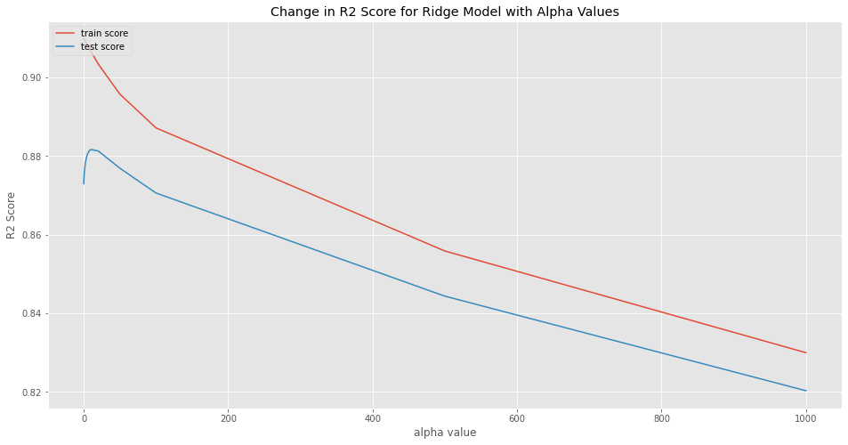

```python
plt.figure(figsize=(16, 8))
plt.plot(cv_results['param_alpha'], cv_results['mean_train_score'])
plt.plot(cv_results['param_alpha'], cv_results['mean_test_score'])
plt.xlabel('alpha value')
plt.ylabel('R2 Score')
plt.title("Change in R2 Score for Ridge Model with Alpha Values")
plt.legend(['train score', 'test score'], loc='upper left')
plt.show()
```

```python
# Retrieving the best Alpha value
model_cv.best_params_
```

```
{'alpha': 10.0}
```

```python
# Retrieving the Best 5 Fold Test R2 Score
print(f"Best 5 Fold R2 Test Score for Ridge Model : {model_cv.best_score_: .4f}")
```

```
Best 5 Fold R2 Test Score for Ridge Model :  0.8817
```

```python
alpha = model_cv.best_params_['alpha']
ridge = Ridge(alpha=alpha)

ridge.fit(X_train, y_train)
ridge.coef_
```

```
array([ 0.09888762, -0.00361851,  0.05242165, -0.0125933 , -0.01724861,
       -0.00226366,  0.03869387, -0.02077955,  0.24578574, -0.00664251,
        0.01208409, -0.03566483, -0.08366253,  0.01087849,  0.03639467,
        0.12319344, -0.01740277,  0.01388488,  0.00902977, -0.00312701,
        0.06582096,  0.18316916, -0.14491062,  0.01727544, -0.0321664 ,
        0.21448214,  0.13205898, -0.03073195, -0.03507043, -0.08403131,
        0.0135035 , -0.01482957,  0.2386954 , -0.2163309 , -0.13233484,
       -0.17521555, -0.03221843,  0.03156099, -0.24107661, -0.02415214,
        0.21711897, -0.24516179, -0.07161846, -0.0941159 , -0.01415299,
        0.07484668,  0.03548093, -0.03431254, -0.11570031, -0.03862138,
       -0.09699315, -0.04054408, -0.07297163,  0.04353176, -0.09538852,
       -0.06186183,  0.10742798, -0.00607488, -0.11750188, -0.15387579,
        0.13257085, -0.03310529, -0.00774022, -0.01963643, -0.14224982,
        0.03835359])
```

```python
# predict
y_train_pred = ridge.predict(X_train)
print("Train R2 Score : ",r2_score(y_true=y_train, y_pred=y_train_pred))
y_test_pred_ridge = ridge.predict(X_test[cols])
print("Test R2 Score : ",r2_score(y_true=y_test, y_pred=y_test_pred_ridge))
```

```
Train R2 Score :  0.9046666161942706
Test R2 Score :  0.864612795604073
```

### Model 2 - Lasso

The next model would be **Lasso Regression** Model. To find the best alpha value let's use **GridSearch.**

To select the best model and for cross-validation purpose I'm using the **R2 Score** as a metric

```python
params = {
    'alpha':[
        0.00001, 0.0001, 0.001, 0.01, 0.05, 0.1, 0.15]
}
```

```python
lasso = Lasso()

# 5 Cross Validation
folds = 5
model_cv = GridSearchCV(
    estimator = lasso,
    param_grid = params,
    scoring= 'r2',
    cv = folds,
    return_train_score=True,
    verbose = 1,
    n_jobs=-1
)

model_cv.fit(X_train, y_train)
```

```
Fitting 5 folds for each of 7 candidates, totalling 35 fits
```

```
GridSearchCV(cv=5, estimator=Lasso(), n_jobs=-1,
             param_grid={'alpha': [1e-05, 0.0001, 0.001, 0.01, 0.05, 0.1,
                                   0.15]},
             return_train_score=True, scoring='r2', verbose=1)
```

```python
cv_results = pd.DataFrame(model_cv.cv_results_)
cv_results.head()
```

|  | mean_fit_time | std_fit_time | mean_score_time | std_score_time | param_alpha | params | split0_test_score | split1_test_score | split2_test_score | split3_test_score | split4_test_score | mean_test_score | std_test_score | rank_test_score | split0_train_score | split1_train_score | split2_train_score | split3_train_score | split4_train_score | mean_train_score | std_train_score |
| --- | --- | --- | --- | --- | --- | --- | --- | --- | --- | --- | --- | --- | --- | --- | --- | --- | --- | --- | --- | --- | --- |
| 0 | 0.1311 | 0.0156 | 0.0045 | 0.0005 | 0.0 | {'alpha': 1e-05} | 0.8680 | 0.8971 | 0.8840 | 0.9151 | 0.8021 | 0.8733 | 0.0388 | 3 | 0.9087 | 0.9022 | 0.9088 | 0.9017 | 0.9278 | 0.9098 | 0.0095 |
| 1 | 0.0863 | 0.0170 | 0.0046 | 0.0008 | 0.0001 | {'alpha': 0.0001} | 0.8688 | 0.8982 | 0.8845 | 0.9155 | 0.8034 | 0.8741 | 0.0386 | 2 | 0.9087 | 0.9021 | 0.9087 | 0.9017 | 0.9278 | 0.9098 | 0.0095 |
| 2 | 0.1002 | 0.0334 | 0.0039 | 0.0010 | 0.001 | {'alpha': 0.001} | 0.8756 | 0.9045 | 0.8854 | 0.9168 | 0.8134 | 0.8791 | 0.0359 | 1 | 0.9077 | 0.9011 | 0.9076 | 0.9002 | 0.9258 | 0.9085 | 0.0092 |
| 3 | 0.0148 | 0.0019 | 0.0042 | 0.0004 | 0.01 | {'alpha': 0.01} | 0.8866 | 0.8993 | 0.8688 | 0.8937 | 0.8007 | 0.8698 | 0.0361 | 4 | 0.8856 | 0.8755 | 0.8849 | 0.8799 | 0.9018 | 0.8855 | 0.0089 |
| 4 | 0.0121 | 0.0054 | 0.0036 | 0.0004 | 0.05 | {'alpha': 0.05} | 0.8431 | 0.8576 | 0.8423 | 0.8621 | 0.7886 | 0.8388 | 0.0263 | 5 | 0.8453 | 0.8352 | 0.8529 | 0.8433 | 0.8660 | 0.8485 | 0.0104 |

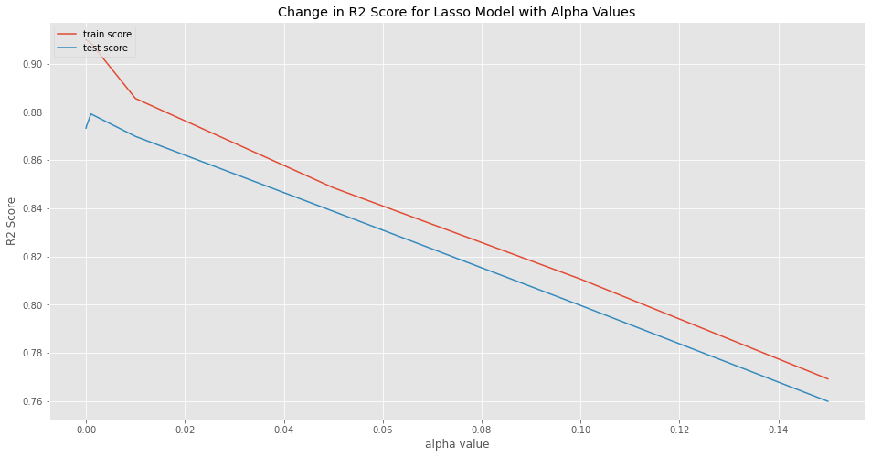

```python
plt.figure(figsize=(16,8))
plt.plot(cv_results['param_alpha'], cv_results['mean_train_score'])
plt.plot(cv_results['param_alpha'], cv_results['mean_test_score'])
plt.xlabel('alpha value')
plt.ylabel('R2 Score')
plt.title('Change in R2 Score for Lasso Model with Alpha Values')
plt.legend(['train score', 'test score'], loc='upper left')
plt.show()
```

```python
# Retrieving the best Alpha value
model_cv.best_params_
```

```
{'alpha': 0.001}
```

```python
# Checking the Mean 5 Fold Test R2 Score
print(f"Best 5 Fold R2 Test Score for Lasso Model : {model_cv.best_score_: .4f}")
```

```
Best 5 Fold R2 Test Score for Lasso Model :  0.8791
```

```python
alpha = model_cv.best_params_['alpha']
lasso = Lasso(alpha=alpha)

lasso.fit(X_train, y_train)
lasso.coef_
```

```
array([ 0.09927616, -0.00462501,  0.05398572, -0.00951203, -0.01349134,
        0.        ,  0.00504239, -0.05849019,  0.31223983, -0.        ,
        0.01126919, -0.03068782, -0.08052324,  0.        ,  0.03233632,
        0.11602094, -0.00892471,  0.01420358,  0.00894034, -0.00163673,
        0.05882614,  0.15995205, -0.15516098,  0.01555904, -0.02924289,
        0.23156075,  0.13158852, -0.        , -0.01214708, -0.05360684,
        0.01143051, -0.        ,  0.29750447, -0.23926936, -0.14437155,
       -0.20580663, -0.06027872,  0.        , -0.30774495, -0.07104702,
        0.24501251, -0.29691219, -0.07674474, -0.10261945, -0.0101684 ,
        0.05858069,  0.02524602, -0.        , -0.0790223 , -0.        ,
       -0.10167976, -0.02823563, -0.07064512,  0.03388473, -0.1093285 ,
       -0.06229782,  0.0928955 , -0.        , -0.12682193, -0.1613008 ,
        0.13830019, -0.01759771,  0.        , -0.01213721, -0.19914441,
        0.0255763 ])
```

```python
# predict
y_train_pred = lasso.predict(X_train)
print("Train R2 Score : ", r2_score(y_true=y_train, y_pred=y_train_pred))
y_test_pred_lasso = lasso.predict(X_test[cols])
print("Test R2 Score : ", r2_score(y_true=y_test, y_pred=y_test_pred_lasso))
```

```
Train R2 Score :  0.905572815825726
Test R2 Score :  0.865507415542214
```

## 6. Final Model Selection

1. **Ridge Model** :
   - **5 Fold CV Best Test** Score : 0.8817
   - **Test Score** : 0.8646
   - **Params** : {alpha=10}
2. **Lasso Model** :
   - **5 Fold CV Best Test** Score : 0.8791
   - **Test Score** : 0.8655
   - **Params** : {alpha=0.001}
- Both Ridge and Lasso are very similar in R2 score but I would select **Lasso** had an internal benefit that it takes the coefficients of features irrelevant to zero hence leading to having lesser and more precise feature bucket.
- This makes the model less complex and more interpretable.

```python
alpha = model_cv.best_params_['alpha']
lasso = Lasso(alpha=alpha)
lasso.fit(X_train, y_train)

# predict
y_train_pred = lasso.predict(X_train)
print("Train R2 Score : ", r2_score(y_true=y_train, y_pred=y_train_pred))
y_test_pred_lasso = lasso.predict(X_test[cols])
print("Test R2 Score : ", r2_score(y_true=y_test, y_pred=y_test_pred_lasso))
```

```
Train R2 Score :  0.905572815825726
Test R2 Score :  0.865507415542214
```

### Actual Vs Predicted

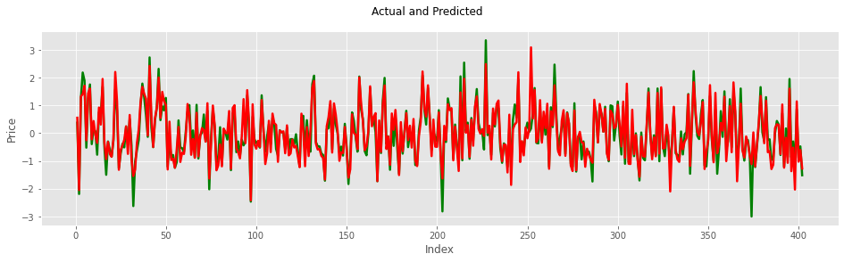

```python
c = [i for i in range(1, X_test.shape[0]+1,1)]

fig = plt.figure(figsize = (16, 4))
plt.plot(c,y_test, color="green", linewidth=2.5, linestyle="-")
plt.plot(c,y_test_pred_lasso, color="red",  linewidth=2.5, linestyle="-")
fig.suptitle('Actual and Predicted')
plt.xlabel('Index')
plt.ylabel('Price')
plt.show()
```

```python
model_parameters = list(lasso.coef_)
model_parameters.insert(0, lasso.intercept_)
model_parameters = [round(x, 3) for x in model_parameters]
cols = X_train.columns
cols = cols.insert(0, "constant")
lasso_coef = pd.DataFrame(list(zip(cols, model_parameters)))
lasso_coef.columns = ['Feaure','Coef']
```

#### Observing final model coefficients

```python
lasso_coef.reindex(lasso_coef.Coef.abs().sort_values(ascending=False).index)
```

|  | Feaure | Coef |
| --- | --- | --- |
| 9 | GrLivArea | 0.312 |
| 39 | OverallQual_7 | -0.308 |
| 33 | Neighborhood_Crawfor | 0.298 |
| 42 | OverallCond_4 | -0.297 |
| 41 | OverallQual_9 | 0.245 |
| 34 | Neighborhood_Edwards | -0.239 |
| 26 | OverallQual_simpleclusters | 0.232 |
| 0 | constant | 0.217 |
| 36 | OverallQual_4 | -0.206 |
| 65 | SaleCondition_Family | -0.199 |
| 60 | KitchenQual_TA | -0.161 |
| 22 | total_sf_area | 0.160 |
| 23 | age | -0.155 |
| 35 | Neighborhood_IDOTRR | -0.144 |
| 61 | Functional_Typ | 0.138 |
| 27 | OverallCond_simpleclusters | 0.132 |
| 59 | KitchenQual_Gd | -0.127 |
| 16 | GarageCars | 0.116 |
| 55 | BsmtFinType2_BLQ | -0.109 |
| 44 | OverallCond_7 | -0.103 |
| 51 | BsmtQual_Fa | -0.102 |
| 1 | LotArea | 0.099 |
| 57 | CentralAir_Y | 0.093 |
| 13 | KitchenAbvGr | -0.081 |
| 49 | ExterQual_TA | -0.079 |
| 43 | OverallCond_5 | -0.077 |
| 53 | BsmtExposure_No | -0.071 |
| 40 | OverallQual_8 | -0.071 |
| 56 | HeatingQC_TA | -0.062 |
| 37 | OverallQual_5 | -0.060 |
| 21 | total_bathroom_area | 0.059 |
| 46 | Exterior1st_BrkFace | 0.059 |
| 8 | 2ndFlrSF | -0.058 |
| 3 | BsmtFinSF1 | 0.054 |
| 30 | MSZoning_RM | -0.054 |
| 54 | BsmtFinType1_GLQ | 0.034 |
| 15 | Fireplaces | 0.032 |
| 12 | BedroomAbvGr | -0.031 |
| 25 | years_passed_since_garageblt | -0.029 |
| 52 | BsmtQual_Gd | -0.028 |
| 66 | SaleCondition_Normal | 0.026 |
| 47 | Exterior2nd_VinylSd | 0.025 |
| 62 | GarageType_Attchd | -0.018 |
| 24 | years_passed_since_sold | 0.016 |
| 18 | WoodDeckSF | 0.014 |
| 5 | BsmtUnfSF | -0.013 |
| 29 | MSZoning_RL | -0.012 |
| 64 | GarageFinish_Unf | -0.012 |
| 31 | LotShape_Reg | 0.011 |
| 11 | FullBath | 0.011 |
| 4 | BsmtFinSF2 | -0.010 |
| 45 | RoofStyle_Gable | -0.010 |
| 19 | OpenPorchSF | 0.009 |
| 17 | GarageArea | -0.009 |
| 2 | MasVnrArea | -0.005 |
| 7 | 1stFlrSF | 0.005 |
| 20 | EnclosedPorch | -0.002 |
| 63 | GarageType_Detchd | 0.000 |
| 10 | BsmtFullBath | -0.000 |
| 32 | LandContour_Lvl | -0.000 |
| 14 | TotRmsAbvGrd | 0.000 |
| 58 | Electrical_SBrkr | -0.000 |
| 48 | ExterQual_Gd | -0.000 |
| 6 | TotalBsmtSF | 0.000 |
| 28 | MSSubClass_50 | -0.000 |
| 38 | OverallQual_6 | 0.000 |
| 50 | ExterCond_Fa | -0.000 |

## 7. Conclusion

- **Final Model Specs -**
  - Lasso [alpha : 0.001]
  - Number of Features : 66
  - Train R2 Score : 0.905572815825726
  - Test R2 Score : 0.865507415542214
- **Train Variance Explained** : 90.5%
- **Test Variance Explained** : 86.5%
- A difference of ~**4%** between Train and Test R2 Score let's to know that our model is robust and well-trained and not overfitted on our train data.

#### Top 5 Features :

1. **GrLivArea**
2. **OverallQual_7**
3. **Neighborhood_Crawfor**
4. **OverallCond_4**
5. **OverallQual_9**

## PDF - Question 1

```python
final_feats = cols.tolist()
final_feats.remove("constant")
len(final_feats)
```

```
66
```

```python
alpha = 20
ridge = Ridge(alpha=alpha)
ridge.fit(X_train, y_train)

# predict
y_train_pred = ridge.predict(X_train)
print("Train R2 Score : ", r2_score(y_true=y_train, y_pred=y_train_pred))
y_test_pred_ridge = ridge.predict(X_test[final_feats])
print("Test R2 Score : ", r2_score(y_true=y_test, y_pred=y_test_pred_ridge))
```

```
Train R2 Score :  0.9022898483525895
Test R2 Score :  0.8636935680991624
```

```python
alpha = 0.002
lasso = Lasso(alpha=alpha)
lasso.fit(X_train, y_train)

# predict
y_train_pred = lasso.predict(X_train)
print("Train R2 Score : ",r2_score(y_true=y_train, y_pred=y_train_pred))
y_test_pred_lasso = lasso.predict(X_test[final_feats])
print("Test R2 Score : ",r2_score(y_true=y_test, y_pred=y_test_pred_lasso))
```

```
Train R2 Score :  0.9034872170659044
Test R2 Score :  0.8665120508106925
```

```python
model_parameters = list(lasso.coef_)
model_parameters.insert(0, lasso.intercept_)
model_parameters = [round(x, 3) for x in model_parameters]
lasso_coef = pd.DataFrame(list(zip(cols, model_parameters)))
lasso_coef.columns = ['Feaure','Coef']
```

- Checking changes to the Top 5 predictor features

```python
lasso_coef.reindex(lasso_coef.Coef.abs().sort_values(ascending=False).index)
```

|  | Feaure | Coef |
| --- | --- | --- |
| 9 | GrLivArea | 0.296 |
| 41 | OverallQual_9 | 0.277 |
| 33 | Neighborhood_Crawfor | 0.274 |
| 42 | OverallCond_4 | -0.264 |
| 39 | OverallQual_7 | -0.236 |
| 34 | Neighborhood_Edwards | -0.223 |
| 26 | OverallQual_simpleclusters | 0.221 |
| 22 | total_sf_area | 0.173 |
| 23 | age | -0.161 |
| 60 | KitchenQual_TA | -0.148 |
| 36 | OverallQual_4 | -0.148 |
| 0 | constant | 0.145 |
| 27 | OverallCond_simpleclusters | 0.132 |
| 61 | Functional_Typ | 0.131 |
| 65 | SaleCondition_Family | -0.116 |
| 16 | GarageCars | 0.114 |
| 59 | KitchenQual_Gd | -0.109 |
| 1 | LotArea | 0.098 |
| 35 | Neighborhood_IDOTRR | -0.090 |
| 44 | OverallCond_7 | -0.082 |
| 13 | KitchenAbvGr | -0.082 |
| 49 | ExterQual_TA | -0.073 |
| 53 | BsmtExposure_No | -0.069 |
| 57 | CentralAir_Y | 0.067 |
| 56 | HeatingQC_TA | -0.062 |
| 43 | OverallCond_5 | -0.061 |
| 21 | total_bathroom_area | 0.060 |
| 3 | BsmtFinSF1 | 0.056 |
| 55 | BsmtFinType2_BLQ | -0.054 |
| 51 | BsmtQual_Fa | -0.051 |
| 8 | 2ndFlrSF | -0.045 |
| 38 | OverallQual_6 | 0.043 |
| 30 | MSZoning_RM | -0.038 |
| 15 | Fireplaces | 0.035 |
| 12 | BedroomAbvGr | -0.033 |
| 54 | BsmtFinType1_GLQ | 0.030 |
| 52 | BsmtQual_Gd | -0.027 |
| 25 | years_passed_since_garageblt | -0.027 |
| 46 | Exterior1st_BrkFace | 0.025 |
| 66 | SaleCondition_Normal | 0.020 |
| 47 | Exterior2nd_VinylSd | 0.019 |
| 24 | years_passed_since_sold | 0.013 |
| 18 | WoodDeckSF | 0.013 |
| 11 | FullBath | 0.011 |
| 4 | BsmtFinSF2 | -0.011 |
| 5 | BsmtUnfSF | -0.011 |
| 7 | 1stFlrSF | 0.010 |
| 62 | GarageType_Attchd | -0.008 |
| 45 | RoofStyle_Gable | -0.008 |
| 19 | OpenPorchSF | 0.008 |
| 64 | GarageFinish_Unf | -0.006 |
| 37 | OverallQual_5 | -0.003 |
| 31 | LotShape_Reg | 0.003 |
| 20 | EnclosedPorch | -0.002 |
| 17 | GarageArea | -0.002 |
| 2 | MasVnrArea | -0.002 |
| 14 | TotRmsAbvGrd | 0.000 |
| 63 | GarageType_Detchd | 0.000 |
| 32 | LandContour_Lvl | -0.000 |
| 58 | Electrical_SBrkr | -0.000 |
| 6 | TotalBsmtSF | 0.000 |
| 10 | BsmtFullBath | -0.000 |
| 28 | MSSubClass_50 | -0.000 |
| 29 | MSZoning_RL | -0.000 |
| 50 | ExterCond_Fa | -0.000 |
| 48 | ExterQual_Gd | -0.000 |
| 40 | OverallQual_8 | -0.000 |

## PDF - Question 3

- Removing Top 5 Predictors and running Lasso again

```python
final_feats.remove("GrLivArea")
final_feats.remove("OverallQual_9")
final_feats.remove("Neighborhood_Crawfor")
final_feats.remove("OverallCond_4")
final_feats.remove("OverallQual_7")
```

```python
alpha = 0.001
lasso = Lasso(alpha=alpha)
lasso.fit(X_train[final_feats], y_train)

# predict
y_train_pred = lasso.predict(X_train[final_feats])
print("Train R2 Score : ",r2_score(y_true=y_train, y_pred=y_train_pred))
y_test_pred_lasso = lasso.predict(X_test[final_feats])
print("Test R2 Score : ",r2_score(y_true=y_test, y_pred=y_test_pred_lasso))
```

```
Train R2 Score :  0.894456592995278
Test R2 Score :  0.8481727211332567
```

```python
model_parameters = list(lasso.coef_)
model_parameters.insert(0, lasso.intercept_)
model_parameters = [round(x, 3) for x in model_parameters]
cols = X_train[final_feats].columns
cols = cols.insert(0, "constant")
lasso_coef = pd.DataFrame(list(zip(cols, model_parameters)))
lasso_coef.columns = ['Feaure','Coef']
```

- Checking changes to the Top 5 predictor features

```python
lasso_coef.reindex(lasso_coef.Coef.abs().sort_values(ascending=False).index)
```

|  | Feaure | Coef |
| --- | --- | --- |
| 21 | total_sf_area | 0.547 |
| 32 | Neighborhood_Edwards | -0.254 |
| 55 | KitchenQual_TA | -0.233 |
| 0 | constant | 0.225 |
| 60 | SaleCondition_Family | -0.211 |
| 54 | KitchenQual_Gd | -0.196 |
| 34 | OverallQual_4 | -0.185 |
| 33 | Neighborhood_IDOTRR | -0.171 |
| 56 | Functional_Typ | 0.167 |
| 44 | ExterQual_TA | -0.163 |
| 22 | age | -0.160 |
| 6 | TotalBsmtSF | -0.148 |
| 26 | OverallCond_simpleclusters | 0.146 |
| 52 | CentralAir_Y | 0.144 |
| 15 | GarageCars | 0.134 |
| 25 | OverallQual_simpleclusters | 0.130 |
| 37 | OverallQual_8 | 0.127 |
| 39 | OverallCond_7 | -0.098 |
| 12 | KitchenAbvGr | -0.098 |
| 1 | LotArea | 0.094 |
| 41 | Exterior1st_BrkFace | 0.088 |
| 43 | ExterQual_Gd | -0.086 |
| 29 | MSZoning_RM | -0.084 |
| 50 | BsmtFinType2_BLQ | -0.084 |
| 48 | BsmtExposure_No | -0.078 |
| 46 | BsmtQual_Fa | -0.077 |
| 36 | OverallQual_6 | 0.070 |
| 51 | HeatingQC_TA | -0.068 |
| 47 | BsmtQual_Gd | -0.066 |
| 3 | BsmtFinSF1 | 0.055 |
| 20 | total_bathroom_area | 0.054 |
| 11 | BedroomAbvGr | -0.051 |
| 49 | BsmtFinType1_GLQ | 0.043 |
| 38 | OverallCond_5 | -0.042 |
| 14 | Fireplaces | 0.040 |
| 42 | Exterior2nd_VinylSd | 0.038 |
| 57 | GarageType_Attchd | -0.038 |
| 31 | LandContour_Lvl | -0.033 |
| 13 | TotRmsAbvGrd | 0.028 |
| 28 | MSZoning_RL | -0.028 |
| 7 | 1stFlrSF | 0.025 |
| 61 | SaleCondition_Normal | 0.025 |
| 27 | MSSubClass_50 | -0.024 |
| 5 | BsmtUnfSF | -0.023 |
| 45 | ExterCond_Fa | -0.021 |
| 16 | GarageArea | -0.020 |
| 23 | years_passed_since_sold | 0.016 |
| 10 | FullBath | 0.016 |
| 40 | RoofStyle_Gable | -0.016 |
| 4 | BsmtFinSF2 | -0.015 |
| 24 | years_passed_since_garageblt | -0.014 |
| 17 | WoodDeckSF | 0.010 |
| 8 | 2ndFlrSF | -0.009 |
| 19 | EnclosedPorch | -0.008 |
| 59 | GarageFinish_Unf | -0.004 |
| 30 | LotShape_Reg | 0.003 |
| 58 | GarageType_Detchd | 0.000 |
| 2 | MasVnrArea | -0.000 |
| 9 | BsmtFullBath | -0.000 |
| 53 | Electrical_SBrkr | 0.000 |
| 18 | OpenPorchSF | -0.000 |
| 35 | OverallQual_5 | 0.000 |